# Informe

Alfredo Quezada

2022-09-07

# Analisis exploratorio:

Lo primero que haremos es el analisis exploratorio del data set, pero antes de entrar de lleno a eso, lo primero sera limpiar lo mas que se pueda el data set:

```r
library(wordcloud2)
library(ggplot2)


#lectura y limpieza del data set
data<- read.csv('train.csv')

data$text<-gsub("#[A-Za-z0-9]+|@[A-Za-z0-9]+|\\w+(?:\\.\\w+)*/\\S+", "", data$text)
data$text<-toupper(data$text)
data$text<-gsub("HTTP://","",data$text)
data$text<-gsub("HTTPS://","",data$text)
data$text<-gsub("[^\x01-\x7F]", "",data$text)
data$text<-gsub("B&amp;N", "",data$text)
data$text<-gsub("#", "",data$text)
data$text<-gsub('(s+)(A|AN|AND|THE|I)(s+)', '', data$text)
data$text<-gsub(':', '', data$text)
data$text<-gsub("'", '', data$text)
data$text<-gsub("--|", '', data$text)
data$text<-gsub('[[:punct:]]', '', data$text)
data$text<-gsub('http",1', '', data$text)
data$text<-gsub('http', '', data$text)
data$text<-gsub('http",0', '', data$text)
data$text<-gsub(' ",0 ', '', data$text)
data$text<-gsub(' ",1 ', '', data$text)
data$id<-toupper(data$id)
data$keyword<-toupper(data$keyword)
data$location<-toupper(data$location)
data[data == ""]<-NA
```

Como podemos ver, lo que se busca es eliminar valores en la variable **texto**, de cierta forma dejar lo mas sola posible la palabra que se encuentra, para ello se eliminaron, enlaces, espacios, numeros y caracteres especiales como se puede observar en las instrucciones anteriores, asi como tambien se pretenden poner en un formato de mayusculas, todas las palabras de la variable, hecho esto, podemos pasar a el analisis exploratorio.

```r
freq<-table(data$keyword, useNA = 'no')
freq
```

```
##
##                ABLAZE              ACCIDENT            AFTERSHOCK
##                    36                    35                    34
##   AIRPLANE%20ACCIDENT             AMBULANCE           ANNIHILATED
##                    35                    38                    34
##          ANNIHILATION            APOCALYPSE            ARMAGEDDON
##                    29                    32                    42
##                  ARMY                 ARSON              ARSONIST
##                    34                    32                    34
##                ATTACK              ATTACKED             AVALANCHE
##                    36                    35                    30
##                BATTLE             BIOTERROR          BIOTERRORISM
##                    26                    37                    30
##                 BLAZE               BLAZING              BLEEDING
##                    38                    34                    35
##             BLEW%20UP                BLIGHT              BLIZZARD
##                    33                    32                    37
##                 BLOOD                BLOODY            BLOWN%20UP
##                    35                    35                    33
##            BODY%20BAG        BODY%20BAGGING           BODY%20BAGS
##                    33                    33                    41
##                  BOMB                BOMBED               BOMBING
##                    34                    38                    29
##     BRIDGE%20COLLAPSE   BUILDINGS%20BURNING BUILDINGS%20ON%20FIRE
##                    35                    35                    33
##                BURNED               BURNING   BURNING%20BUILDINGS
##                    33                    34                    37
##          BUSH%20FIRES            CASUALTIES              CASUALTY
##                    25                    35                    34
##           CATASTROPHE          CATASTROPHIC  CHEMICAL%20EMERGENCY
##                    36                    30                    33
##          CLIFF%20FALL              COLLAPSE             COLLAPSED
##                    36                    34                    35
##               COLLIDE              COLLIDED             COLLISION
##                    34                    40                    39
##                 CRASH               CRASHED                 CRUSH
##                    33                    34                    37
##               CRUSHED                CURFEW               CYCLONE
##                    31                    37                    32
##                DAMAGE                DANGER                  DEAD
```

[output cut: 94 more lines]

```
##                    36                    32                    31
##           TRAUMATISED               TROUBLE               TSUNAMI
##                    35                    33                    34
##               TWISTER               TYPHOON              UPHEAVAL
##                    40                    38                    38
##       VIOLENT%20STORM               VOLCANO            WAR%20ZONE
##                    33                    27                    24
##                WEAPON               WEAPONS             WHIRLWIND
##                    39                    39                    39
##          WILD%20FIRES              WILDFIRE             WINDSTORM
##                    31                    33                    40
##               WOUNDED                WOUNDS                 WRECK
##                    37                    33                    37
##              WRECKAGE               WRECKED
##                    39                    39
```

Aca podemos ver, en forma de tabla, las palabras con mayor frecuencia dentro del data set.

```r
# Nube de palabras
wordcloud2(data = freq, size = 0.15, shape = "cloud",
           color="random-dark", ellipticity = 0.5)
```

[interactive chart not shown]

Aca podmeos verlo de otra forma, podemos ver la nube de palabras de la categoria.

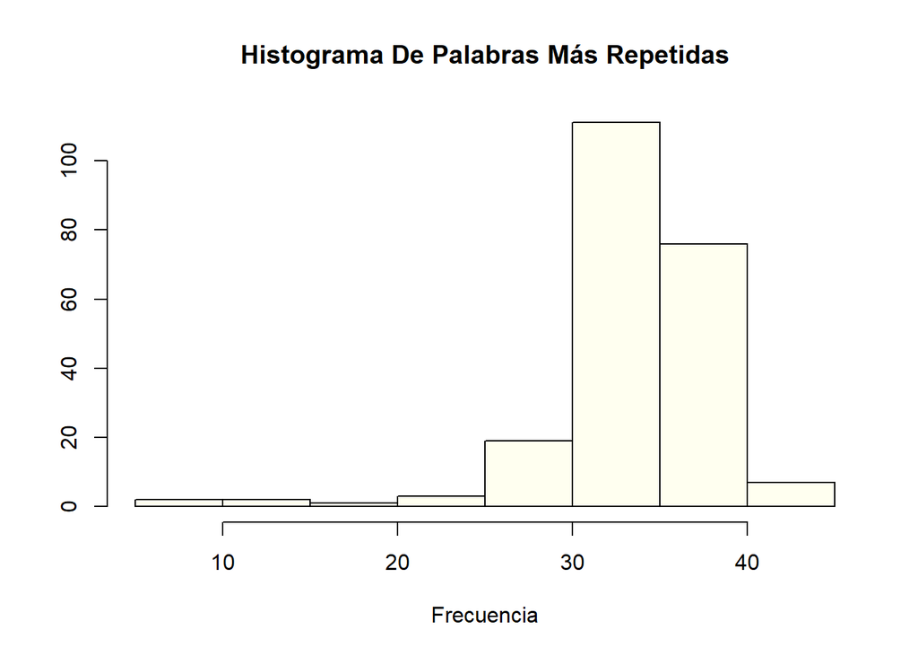

```r
# Histograma
hist(x = freq, main = "Histograma De Palabras Más Repetidas",
     xlab = "Frecuencia", ylab = "",
     col = "ivory")
```

Representacion visual de las palabras mas repetidas.

```r
# Nube de palabras categorizadas como NO DESASTRES
wordcloud2(data = freq_no_disaster, size = 0.2, shape = "cloud",
           color="random-dark", ellipticity = 0.5)
```

[interactive chart not shown]

Aca podemos ver la nube de palabras de la categoria **NO DESASTRES**

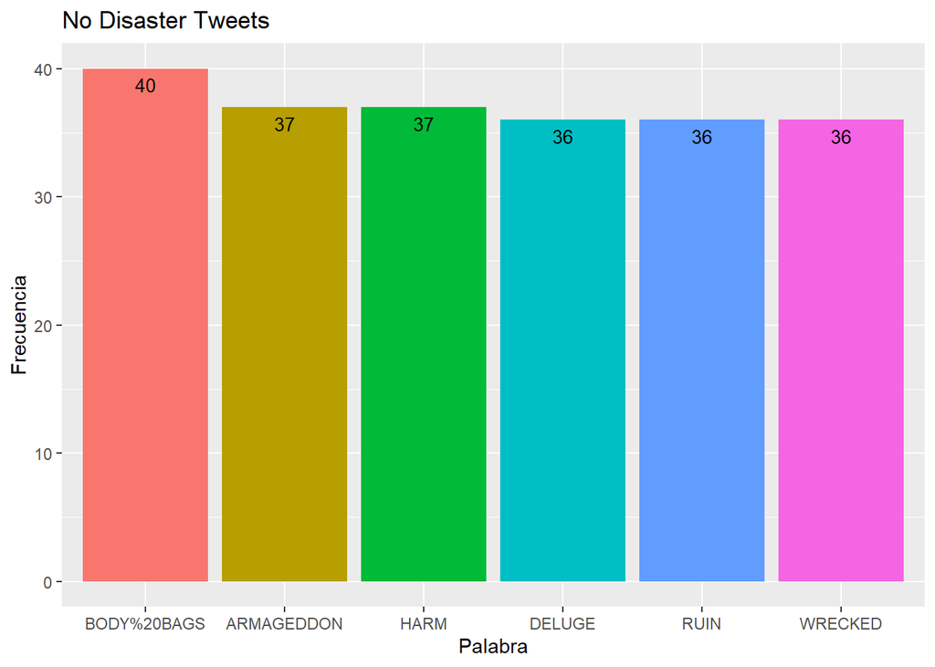

```r
# Grafica de las palabras claves de NO DESASTRES
ggplot(data=h1, aes(x=Var1, y=Freq, fill=Var1)) +
  geom_bar(stat="identity", position=position_dodge())+
  geom_text(aes(label=as.integer(Freq)), vjust=1.6, color="black",
            position = position_dodge(0.9), size=3.5)+
  labs(title="No Disaster Tweets",x='Palabra', y="Frecuencia")+
  theme(legend.position="none")
```

```r
disaster<-subset(x = data, subset = target == 1, select = c("keyword"))
freq_disaster<-table(disaster$keyword)
tabla_ordenada2<-freq_disaster[order(freq_disaster, decreasing = TRUE, na.last = TRUE)]
h2<-head(tabla_ordenada2)
h2<-as.data.frame(h2)
```

Asi como tambien, visto de una forma mucho mas generica, esta seria la grafica de las palabras clave para la variable de **NO DESASTRES**, en la cual podemos ver que resaltan **HARM**, **ARMAGEDON** entre otras.

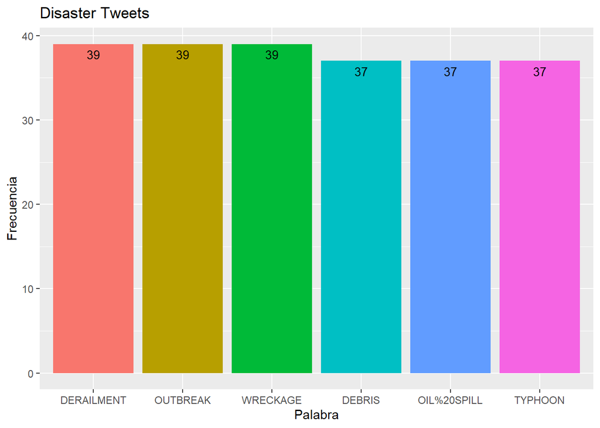

```r
ggplot(data=h2, aes(x=Var1, y=Freq, fill=Var1)) +
  geom_bar(stat="identity", position=position_dodge())+
  geom_text(aes(label=as.integer(Freq)), vjust=1.6, color="black",
            position = position_dodge(0.9), size=3.5)+
  labs(title="Disaster Tweets",x='Palabra', y="Frecuencia")+
  theme(legend.position="none")
```

De igal forma, pero ahora para las palabras clave categorizadas como: **DESASTRES**, en las que se pueden ven **DEBRIS**, **OILSPILL**, entre otros.

```r
wordcloud2(data = freq_disaster, size = 0.2, shape = "cloud",
           color="random-dark", ellipticity = 0.5)
```

[interactive chart not shown]

Y por ultimo, podemos ver la nube de palabras de la categoria **DESASTRES**.

## Analsis de sentimientos:

Para esta parte, lo que se busco fue asociar palabras a sentiemientos, por lo cual, se obtuvo lo siguiente:

```r
#Palabras mas usadas o frecuentes
head(dtm_d)
```

```
##        word freq
## fire   fire  357
## amp     amp  300
## bomb   bomb  230
## peopl peopl  197
## burn   burn  178
## time   time  176
```

Como podemos ver, la palabra **fire**, es la que se encuentra en primer lugar, como la que se mas encuentra, seguida la palaba **amp** y sigue la palabra **bomb**

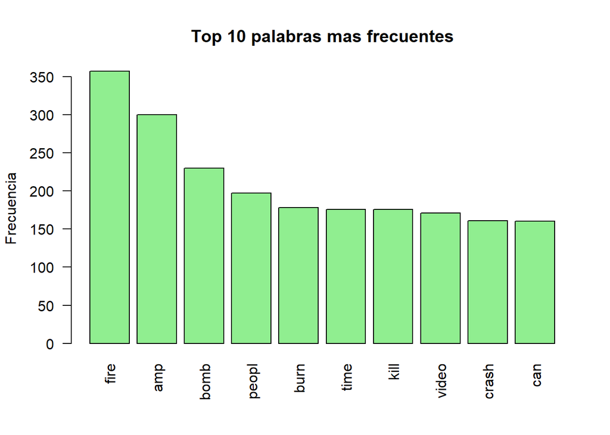

```r
#  Grafico de las palabras mas frecuentes:
barplot(dtm_d[1:10,]$freq, las = 2, names.arg = dtm_d[1:10,]$word,
        col ="lightgreen", main ="Top 10 palabras mas frecuentes",
        ylab = "Frecuencia")
```

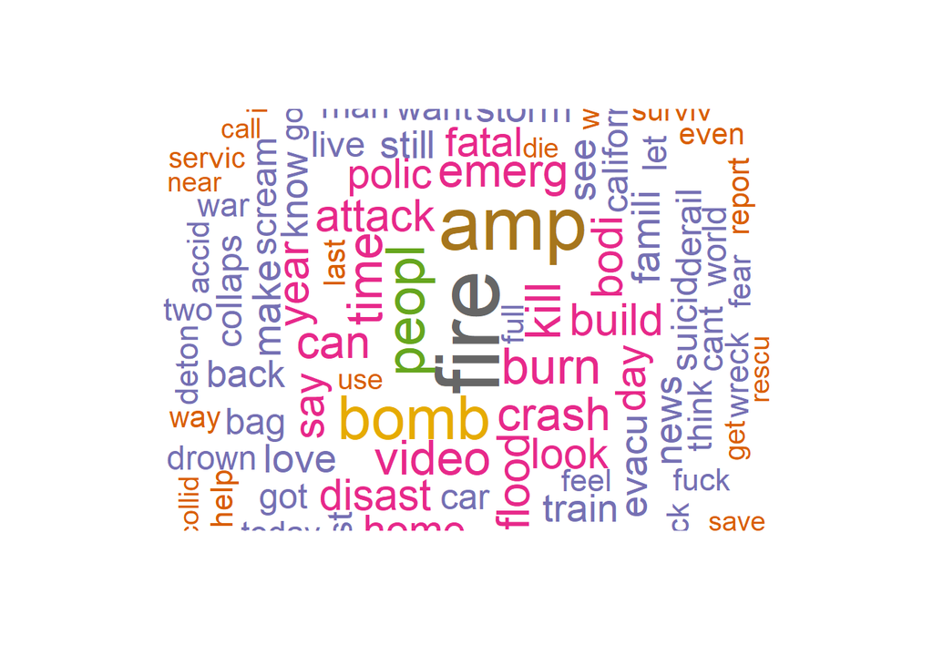

```r
set.seed(1234)
wordcloud(words = dtm_d$word, freq = dtm_d$freq, min.freq = 5,
          max.words=100, random.order=FALSE, rot.per=0.40,
          colors=brewer.pal(8, "Dark2"))
```

Visto de una forma mucho mas visual, esta seria la grafica de las palabras que se encuentran como mas frecuentes, en concreto las 10 primeras palabras.

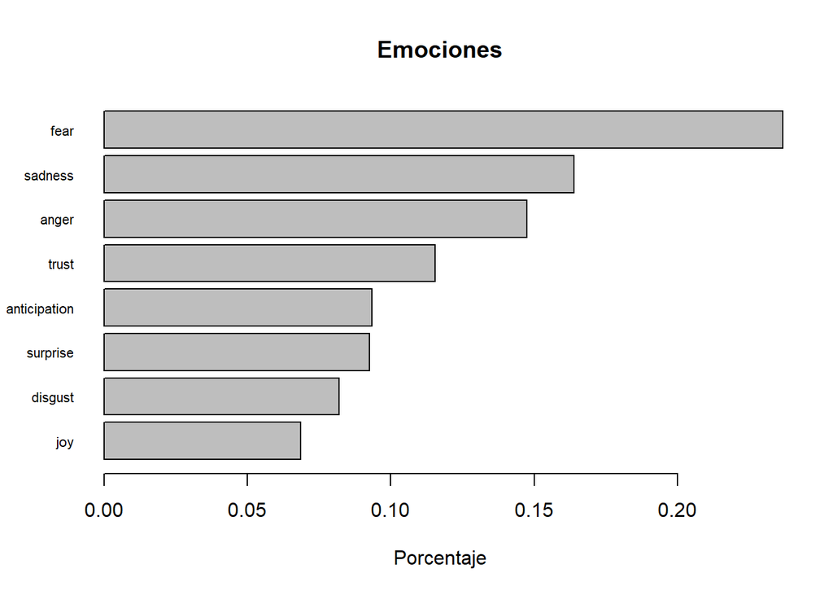

```r
#Grafico de sentimientos
barplot(
  sort(colSums(prop.table(d[, 1:8]))),
  horiz = TRUE,
  cex.names = 0.7,
  las = 1,
  main = "Emociones", xlab="Porcentaje"
)
```

Al final podemos observar que el sentimiento que mayor influencia tiene, o mayor incidencia se encuentra, es el del miedo, seguido de la tristeza, el enojo, la confianza y demas sentimientos, el miedo y la tristreza realmente si no analizamos desde un punto de vista un poco desapacionado, tiene sentido que sean los que mas se encuentren, ya que si lo pensamos en una red social como twitter, donde la mayoria de personas se expresa, es normal encontrar este tipo de sentimiento como los principales.